# Multiple time series: Electricity, beer and chocolate

Benoit Liquet slides by Benoit Liquet

## Multiple time series

Here we illustrate a few important ideas and concepts related to multiple time series data. The monthly supply of electricity (millions of kWh), beer (Ml), and chocolate-based production (tonnes) in Australia over the period January 1958 to December 1990 are available from the Australian Bureau of Statistics (ABS). The three series have been stored in a single file online, which can be read as follows:

```r
class(CBE)
```

```
[1] "data.frame"
```

Now create time series objects for the electricity, beer, and chocolate data. If you omit end, R uses the full length of the vector, and if you omit the month in start, R assumes 1. You can use **plot** with cbind to plot several series

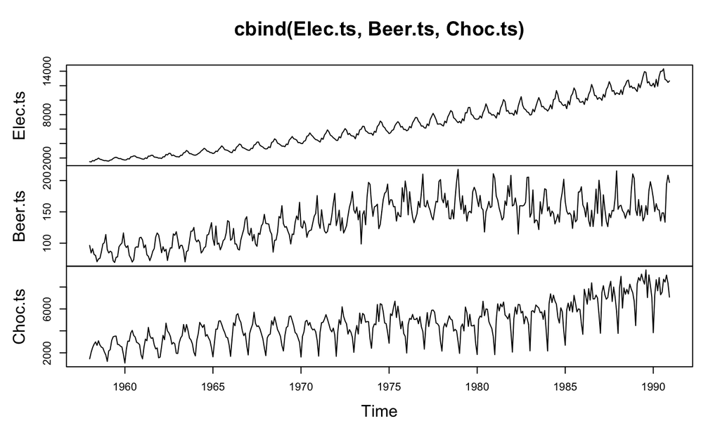

```r
Elec.ts<-ts(CBE[,3],start=1958, freq=12)
Beer.ts<-ts(CBE[,2],start=1958, freq=12)
Choc.ts<-ts(CBE[,1],start=1958, freq=12)
#You can use 'plot' with 'cbind' to plot several series on one figure!
plot(cbind(Elec.ts, Beer.ts, Choc.ts)) # Fig. 1.5.
```

The plots show increasing trends in production for all three goods, partly due to the rising population in Australia from about 10 million to about 18 million over the same period. But notice that electricity production has risen by a factor of 7, and chocolate production by a factor of 4, over this period during which the population has not quite doubled.

## multiple time series

The three series constitute a multiple time series. There are many functions in R for handling more than one series, including **ts.intersect** to obtain the intersection of two series that overlap in time. We now illustrate the use of the intersect function and point out some potential pitfalls in analysing multiple time series. The intersection between the air passenger data and the electricity data is obtained as follows:

```r
#the 'ts.intersect' function for obtaining intersections of two series that overlap in time
data("AirPassengers")
AP <- AirPassengers
AP.elec<-ts.intersect(AP, Elec.ts)
start(AP.elec)
```

```
[1] 1958    1
```

```r
end(AP.elec)
```

```
[1] 1960   12
```

```r
AP.elec[1:3,]
```

```
      AP Elec.ts
[1,] 340    1497
[2,] 318    1463
[3,] 362    1648
```

In the code below, the data for each series are extracted and plotted

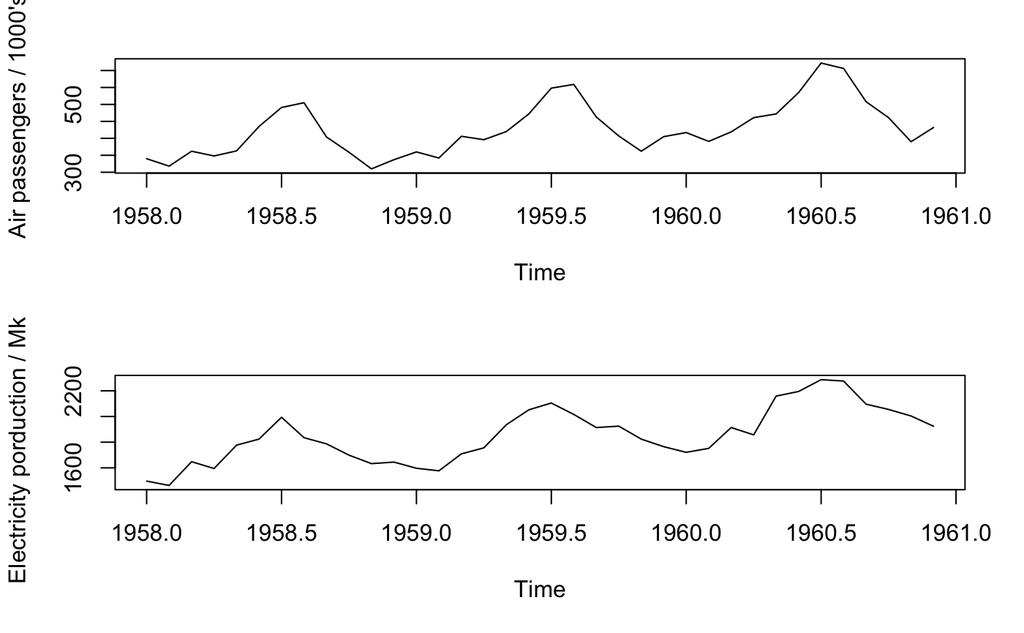

```r
#The data for each series is extracted and plotted
AP<-AP.elec[,1];Elec<-AP.elec[,2]
layout(1:2)
plot(AP, main="", ylab="Air passengers / 1000's") # Fig. 1.7. (oben)
plot(Elec, main="", ylab="Electricity porduction / MkWh") # Fig. 1.7 (unten)
```

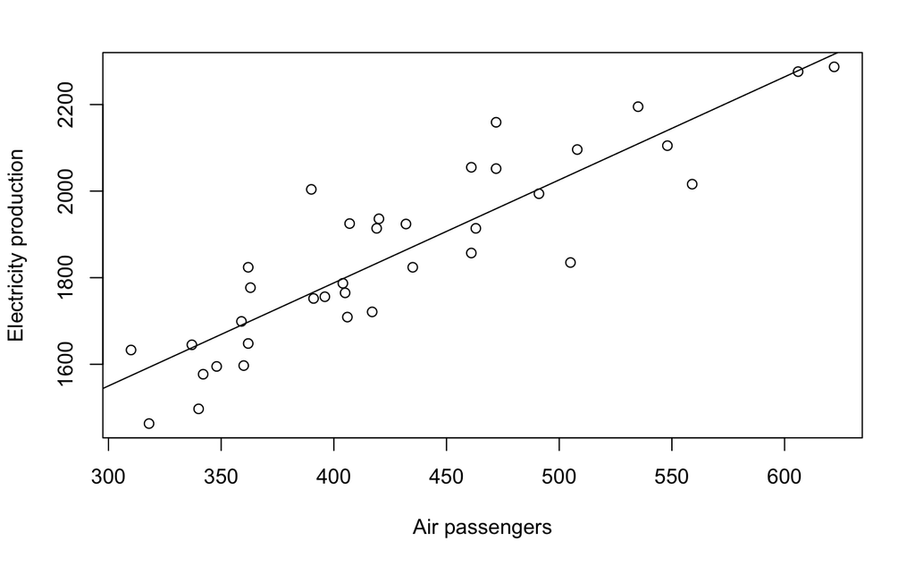

```r
plot(as.vector(AP), as.vector(Elec), xlab="Air passengers", #as.vector is needed to convert "ts" objects to ordinary vectors needed for scatterplot
     ylab="Electricity production") # Fig. 1.8.
abline(reg=lm(Elec~AP)) #Linear model trend line
```

```r
cor(AP, Elec) #Correlation coefficient => CORRELATION DOES NOT IMPLY CAUSATION!!! This is a good example for that!
```

```
[1] 0.8841668
```

## Interpretation

- The two time series are highly correlated, as can be seen in the plots, with a correlation coefficient of 0.88.
- The two time plots look similar and that the scatter plot shows an approximate linear association between the two variables.
- However, it is important to realise that correlation does not imply causation.
- In this case, it is not plausible that higher numbers of air passengers in the United States cause, or are caused by, higher electricity production in Australia.
- A reasonable explanation for the correlation is that the increasing prosperity and technological development in both countries over this period accounts for the increasing trends.
- The two time series also happen to have similar seasonal variations. For these reasons, it is usually appropriate to remove trends and seasonal effects before comparing multiple series. This is often achieved by working with the residuals of a regression model that has deterministic terms to represent the trend and seasonal effects.